Analyzing My Music Taste Examining song characteristics across listening contexts

# Introduction

The idea for this project started earlier this year when the results of my Spotify wrapped were released. I thought their characterization of my listening profile was a little outlandish, albeit somewhat accurate. While I listen to a wide range of genres and artists, Spotify determined that overall, my music taste was “nervous, gloomy, and cathartic”. I found this to be pretty funny, but overall my doubts about this characterization got me thinking deeper about the characteristics of songs I listened to. Broadly speaking, I would say that I listen to music in 3 separate contexts : When I am doing work, when I am hanging out with friends or driving around, and when I am just relaxing/doing anything else. Looking over my playlists, I started to realize that there were some immediate differences in genre and mood when observing playlists made for those 3 contexts, and I was interested to see if any quantitative differences could be observed when taking a deeper look at the song data for the tracks that fell into each of those different listening contexts.

That is essentially the question this analysis aims to answer: What are the differences in characteristics of songs I listen to in different contexts? And furthermore, is there a possible qualitative explanation that can explain why those differences arise?

This project is broken down into 3 main sections. The first will detail the data extraction process through utilizing the Spotify API, and then will describe the data cleaning and wrangling process used to obtain the final dataframe. The next section will be an Exploratory Data Analysis of 3 main audio features that I hypothesize would be different across listening contexts, and an initial attempt at reasoning about observed differences between contexts will be made. Finally, in an attempt to build a firmer understanding of the underlying differences between songs in different categories, a standard decision tree and random forest classification model will be built to attempt to classify songs based on their audio features. The decision rules and feature importances will then be examined in order to obtain a deeper understanding of how song characteristics influence the context in which I listen to them. I would also just like to clarify that this is an introductory project done so I can both answer my research question but also practice Data Analysis skills, and as such, the conclusion section will also list out future improvements that could be implemented in order to improve different aspects of this analysis.

# Importing and Wrangling Data

First the necessary libraries are imported. The utilization of each package is described in the comments below.

```r
# For Data Wrangling and Display
library(tidyverse)
library(reshape2)
library(kableExtra)
# Wrapper for the Spotify API
library(spotifyr)
# For Constructing the model
library(caret)
library(randomForest)
library(rpart)
library(caTools)
# For Model Display
library(rattle)
library(rpart.plot)
# Knitting Output and custom formatting
library(knitr)
# Concealing API Key
library(dotenv)
```

Next, the Client and Secret ID keys for accessing the Spotify API are stored as environment variables. As described in the documentation, an access_token object is instantiated, and it will be used in the API calls made later on.

```r
load_dot_env("cred.env")
Sys.setenv(SPOTIFY_CLIENT_ID = Sys.getenv("client_id"))
Sys.setenv(SPOTIFY_CLIENT_SECRET = Sys.getenv("secret_id"))
access_token <- get_spotify_authorization_code()
```

After credentials are established, the next step is to retrieve the playlist data from Spotify. Since the playlists are already organized by category on my Spotify account, 3 separate dataframes are created. Each listening category (night, work, and lounge) is stored in a separate dataframe. Then, the Track name, Track ID, Track Popularity, and Track artist variables are selected. A new column called category is created, and the listening category of each playlist is assigned based on the playlist that is imported. Next, since the spotifyr package parses the API response to store the artist name as a list of lists to handle multiple artists on the same track, the track.artists column is populated by the extracted first element of the artist list, which in this case would be the main artist on the track (i.e. the non-feature artist). Finally, for ease of viewing, the track.artists column is reordered to be the second column in the dataframe.

```r
night_tracks <- get_playlist_tracks('3Mx4GqiZU0pg53fXRXmwQw') %>%
  select(track.name, track.id, track.popularity,track.artists) %>%
  mutate(
    category = "night",
    track.artists = sapply(sapply(track.artists,'[',3),'[',1)
  ) %>%
  relocate(track.artists, .after = track.name)

work_tracks <- get_playlist_tracks('3NPOt1ksKIONHhQrKMzCgn') %>%
  select(track.name, track.id, track.popularity, track.artists) %>%
  mutate(
    category = "work",
    track.artists = sapply(sapply(track.artists,'[',3),'[',1)
  ) %>%
  relocate(track.artists, .after = track.name)

lounge_tracks <- get_playlist_tracks('2kV84OoCK0Y2EuggYvMUTM') %>%
  select(track.name, track.id, track.popularity,track.artists) %>%
  mutate(
    category = "lounge",
    track.artists = sapply(sapply(track.artists,'[',3),'[',1)
  ) %>%
  relocate(track.artists, .after = track.name)
```

To verify that the API response was parsed correctly, the first 5 rows of the output dataframe for the Night Songs are displayed below. As expected, all columns are imported successfully, and the track.artists column was successfully cleaned to display only the main artist on the track.

```r
kbl(head(night_tracks)) %>% kable_material()
```

| track.name | track.artists | track.id | track.popularity | category |
| --- | --- | --- | --- | --- |
| Aokigahara | $uicideboy$ | 0fAaWjBHBkqp5LtTifqWhH | 0 | night |
| I Can Tell | Travis Scott | 2hiuiI3ac0I5kJWtkeGHEL | 58 | night |
| Impossible | Travis Scott | 0IabpxMpUV7waD7U4uDIMJ | 62 | night |
| the ends | Travis Scott | 33zbOXJSwW7uf4VXXWow2O | 63 | night |
| Nightmare | Offset | 7LAhKXDNWwq3CmnFP3UIOP | 62 | night |
| 56 Nights | Future | 2oGY1X7Xd5kyL6B9s19D9A | 62 | night |

Next, the quantitative features of each track in the playlist was obtained. The get_audio_features method was used with the track.id column being passed in as a parameter. For each listening category, the audio features were stored in a separate dataframe.

```r
night_features <- get_track_audio_features(night_tracks$track.id)
work_features <- get_track_audio_features(work_tracks$track.id)
lounge_features <- get_track_audio_features(lounge_tracks$track.id)
```

Finally, the dataframes containing song data and audio features were merged in two steps. The code below first rowbinds the track information for each listening category into one dataframe, and does the same for the audio feature dataframes. Then, the two dataframes are merged into a complete dataframe containing all variables. The track.id column was used as the identifier that binded the dataframes. Finally, extraneous columns such as the uri, type, trackhref, and analysis_url were removed, resulting in the complete dataframe for all variables of analysis across all 3 listening categories.

```r
tracks_complete <- bind_rows(night_tracks, work_tracks, lounge_tracks)
features_complete <- bind_rows(night_features, work_features, lounge_features)
df <- tracks_complete %>%
  left_join(features_complete, by = c("track.id" = "id")) %>%
  select(-c(uri,type,track_href,analysis_url))
```

For reference, the first 5 rows and columns of the complete dataframe are displayed below. This confirms the merge worked as expected, and all variables have been preserved.

```r
df %>%
  head(c(5,5)) %>%
  kbl() %>%
  kable_material()
```

| track.name | track.artists | track.id | track.popularity | category |
| --- | --- | --- | --- | --- |
| Aokigahara | $uicideboy$ | 0fAaWjBHBkqp5LtTifqWhH | 0 | night |
| I Can Tell | Travis Scott | 2hiuiI3ac0I5kJWtkeGHEL | 58 | night |
| Impossible | Travis Scott | 0IabpxMpUV7waD7U4uDIMJ | 62 | night |
| the ends | Travis Scott | 33zbOXJSwW7uf4VXXWow2O | 63 | night |
| Nightmare | Offset | 7LAhKXDNWwq3CmnFP3UIOP | 62 | night |

```r
paste("Number of Rows: ",nrow(df))
```

```
## [1] "Number of Rows:  183"
```

```r
paste("Number of Columns: ",ncol(df))
```

```
## [1] "Number of Columns:  18"
```

```r
paste("Number of NA: ",sum(is.na(df)))
```

```
## [1] "Number of NA:  0"
```

# Exploratory Data Analysis

3 features were chosen to be explored: Popularity, Valence, and Danceability. The distribution and spread of each variable in each category will be examined, and prior to constructing a model, preliminary characteristics of songs from each listening category will be analyzed in an attempt to generally describe optimal songs for each listening context.

## Popularity

Per the Spotify API documentation:

> Popularity: The popularity of the album. The value will be between 0 and 100, with 100 being the most popular.

Next, since popularity is a continuous variable, the distribution across each listening category was examined. Based on the density plot below, track popularity in all 3 listening categories is bimodal. However in the lounge music category, the majority of the data is concentrated between the scores of 0 and 50. In the night and work categories, the majority of data is concentrated between the scores 50 and 80. The local maxima occurs around a score of 10 for the lounge category, a score of 55 for the night category, and a score of 70 for the work category. This indicates that tracks I listen to in a lounge/relaxed context are less popular than tracks I listen to when working, or at night. Based on experience, this could be confounded with the fact that tracks I listen to when working are typically higher energy and more motivational, which tend to be more in line with dominant song conventions found in pop music or popular trap songs. In terms of the night category, I often listen to these songs when I am driving around and hanging out with friends, which means that the songs found in that playlist contain more popular songs that both my friends and I are likely to know, as opposed to songs from my collection that I have a more personal attachment to.

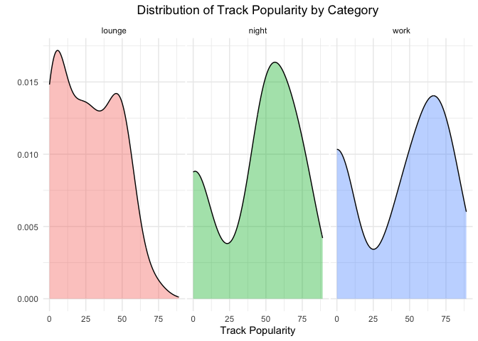

```r
df %>%
  ggplot(aes(x = track.popularity, group = category, fill = category)) +
    geom_density(alpha=0.4) +
    facet_wrap(~category) +
    theme_minimal() +
    theme(
      legend.position="none",
      panel.spacing = unit(0.1, "lines"),
      axis.ticks.x=element_blank(),
      plot.title = element_text(hjust = 0.5)
    ) +
    xlab("Track Popularity") +
    ylab("") +
    ggtitle("Distribution of Track Popularity by Category")
```

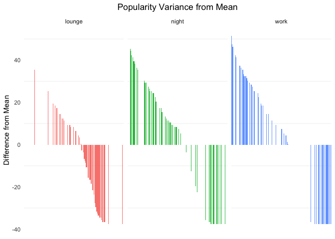

```r
df %>%
  mutate(
    popularity_difference = track.popularity - 37.60656
  ) %>%
    ggplot(aes(
      x=reorder(track.name,-popularity_difference),
      y=popularity_difference,
      fill = category)) +
    geom_col(alpha = 0.9) +
    theme_minimal() +
    theme(
      axis.title.x = element_blank(),
      axis.text.x = element_blank(),
      axis.ticks.x = element_blank(),
      axis.ticks.y = element_blank(),
      legend.position = "none",
      panel.grid.major = element_blank(),
      plot.title = element_text(hjust=0.5)
    ) +
    facet_wrap(~category) +
    ylab("Difference from Mean") +
    ggtitle("Popularity Variance from Mean")
```

```r
df %>%
  group_by(category) %>%
  summarise_at(vars(track.popularity),list(sd=sd)) %>%
  kbl() %>%
  kable_material()
```

| category | sd |
| --- | --- |
| lounge | 20.25617 |
| night | 27.75578 |
| work | 32.05440 |

## Danceability

From the Spotify API documentation:

> Danceability describes how suitable a track is for dancing based on a combination of musical elements including tempo, rhythm stability, beat strength, and overall regularity. A value of 0.0 is least danceable and 1.0 is most danceable.

Similar to the Popularity variable, the distribution of danceability across all 3 categories was examined first. Unlike the track popularity, the distribution of danceability across all 3 categories is unimodal. The lounge category density curve peaks at a score of 0.45, while the night and work categories peak at scores of 0.6 and 0.8 respectively. Intuitively, this also makes sense, since I tend to listen to more high energy and thus danceable tracks when when working. When relaxing, I tend to want to destress and listen to more down tempo and atmospheric compositions, wheras at night I try to find a middle ground. When with friends, we tend to listen to faster paced and harder hitting songs, but the playlist also contains more moody songs that tend to be played late at night. It makes sense that tracks that strike the balance between both of those characteristics have a modal peak in between the other two categories.

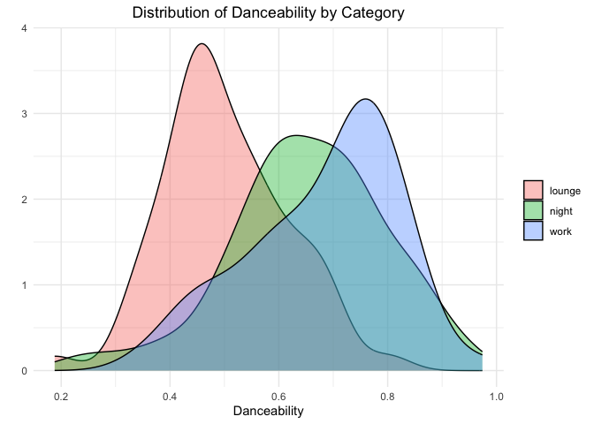

```r
df %>%
  ggplot(aes(x = danceability, fill = category)) +
  geom_density(alpha = 0.4) +
  theme_minimal() +
  theme(
    legend.title = element_blank() ,
    plot.title = element_text(hjust=0.5)
  ) +
  ylab("") +
  xlab("Danceability") +
  ggtitle("Distribution of Danceability by Category")
```

Next, the spread of danceability across categories was examined. Based on the above reasoning, it also makes intuitive sense that the night category has the largest spread. Since it accounts for a wider range of listening contexts, a larger range of danceability scores is expected. However, when examining the mean (indicated by the colored dot on the graph), it is observed that there are more higher tempo tracks in this category than slower, moody tracks. Essentially this indicates that a greater proportion of the songs in this category are oriented towards listening to music with my friends, since the average danceability score is closer to 1.0.

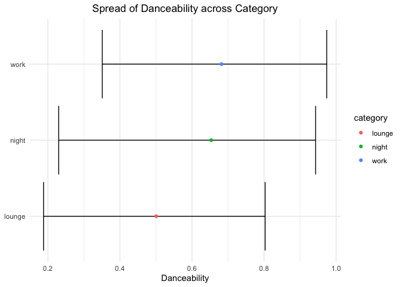

```r
df %>%
  group_by(category) %>%
  summarise_at(vars(danceability),
               list(mean=mean, sd=sd, min=min, max=max)) %>%
  ggplot(aes(x=mean,y=category,fill=category))+
  geom_errorbar(aes(xmin=min,xmax=max)) +
  geom_point(aes(y=category,x=mean,color=category)) +
  theme_minimal() +
  theme(
    axis.title.y = element_blank(),
    plot.title = element_text(hjust=0.5)
  ) +
  xlab("Danceability") +
  ggtitle("Spread of Danceability across Category")
```

## Valence

Finally, the valence value of each track was examined. From the Spotify API documentation, valence is defined as:

> A measure from 0.0 to 1.0 describing the musical positiveness conveyed by a track. Tracks with high valence sound more positive (e.g. happy, cheerful, euphoric), while tracks with low valence sound more negative (e.g. sad, depressed, angry).

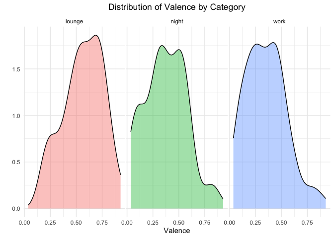

```r
df %>%
  ggplot(aes(x = valence, group = category, fill = category)) +
    geom_density(alpha=0.4) +
    facet_wrap(~category) +
    theme_minimal() +
    theme(
      legend.position="none",
      panel.spacing = unit(0.1, "lines"),
      axis.ticks.x=element_blank(),
      plot.title = element_text(hjust = 0.5)
    ) +
    xlab("Valence") +
    ylab("") +
    ggtitle("Distribution of Valence by Category")
```

When examining the spread of valence across categories, it appears that the work category has the highest range of valence values, followed by the night and lounge categories. Genre differences can again partially explain this observation. The work category tends to have both trap and pop songs, whereas the lounge category tends to have more hip-hop oriented songs. While the night category has both RnB and trap songs, their instrumental palette tends to be darker across the board, which could explain why the valence scores are less diffuse across the dataset.

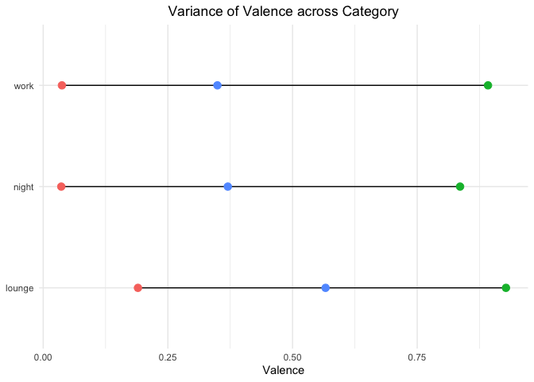

```r
df %>%
  group_by(category) %>%
  summarise_at(vars(valence),
               list(min=min,max=max,mean=mean)) %>%
  melt(id.vars='category') %>%
  ggplot(aes(x=value,y=category)) +
    geom_line() +
    geom_point(aes(color=variable),size=3) +
    theme_minimal() +
    theme(
      legend.position = "none",
      axis.title.y = element_blank(),
      plot.title = element_text(hjust=0.5)
    ) +
    xlab('Valence') +
    ggtitle("Variance of Valence across Category")
```

## EDA Summary

To conclude this section, the differences in means and standard deviations for each statistic are summarized in the graphs below. For track popularity, the night category has the highest mean popularity, followed by the work and lounge categories. For Danceability, the work category has the highest mean, followed by night and lounge categories. For Valence, the lounge category has the highest mean, followed by the night and work categories.

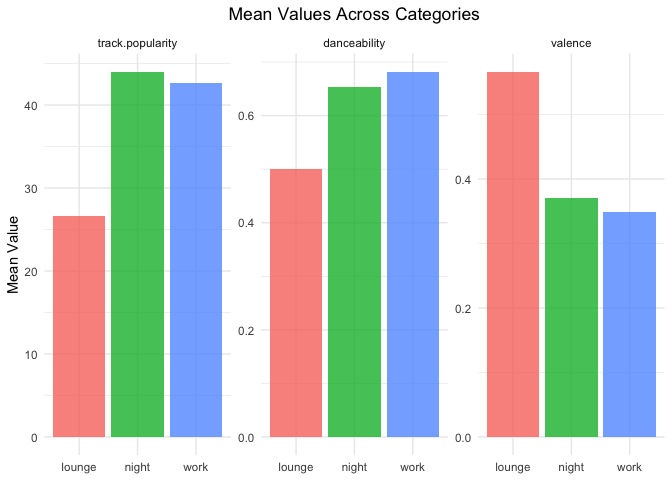

```r
df %>%
  group_by(category) %>%
  summarise(across(where(is.numeric), mean), .groups = 'drop') %>%
  select(category, track.popularity, danceability, valence) %>%
  melt(id.vars='category') %>%
  ggplot(aes(x=category,y=value,fill=category)) +
    geom_bar(stat="identity",position="dodge",alpha=0.8) +
    facet_wrap(~variable,scales="free_y") +
    theme_minimal() +
    theme(
        legend.position="none",
        axis.title.x = element_blank(),
        plot.title = element_text(hjust=0.5)
    ) +
    ylab("Mean Value") +
    ggtitle("Mean Values Across Categories")
```

For standard deviations, the ranking is as follows. For track popularity, the work category has the highest standard deviation, followed by the night and lounge categories. For Danceability, the night category has the highest standard deviation, followed by the work and lounge categories. Finally, for the valence score, the night category has the highest standard deviation, followed by the work and lounge categories.

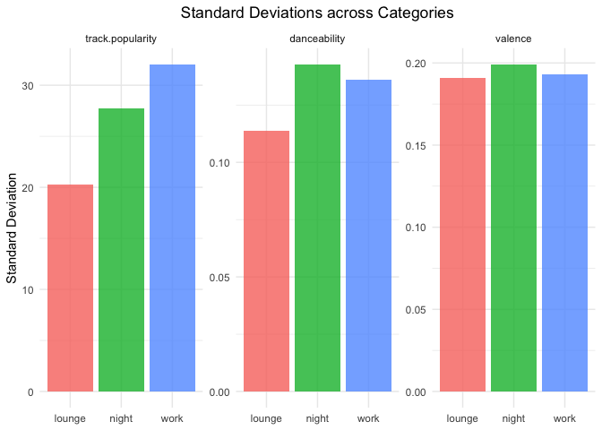

```r
df %>%
  group_by(category) %>%
  summarise(across(where(is.numeric), sd), .groups = 'drop') %>%
  select(category, track.popularity, danceability, valence) %>%
  melt(id.vars='category') %>%
  ggplot(aes(x=category,y=value,fill=category)) +
    geom_bar(stat="identity",position="dodge",alpha=0.8) +
    facet_wrap(~variable,scales="free_y") +
    theme_minimal() +
    theme(
        legend.position="none",
        axis.title.x = element_blank(),
        plot.title = element_text(hjust=0.5)
    ) +
    ylab("Standard Deviation") +
    ggtitle("Standard Deviations across Categories")
```

For confirmation of the above values, the specific values of means and standard deviations across categories are listed below.

```r
df %>%
  group_by(category) %>%
  summarise(across(where(is.numeric), mean), .groups = 'drop') %>%
  select(category, track.popularity, danceability, valence) %>%
  kbl() %>%
  kable_material()
```

| category | track.popularity | danceability | valence |
| --- | --- | --- | --- |
| lounge | 26.59016 | 0.5007049 | 0.5662131 |
| night | 44.01639 | 0.6533770 | 0.3702033 |
| work | 42.68852 | 0.6819016 | 0.3493492 |

```r
df %>%
  group_by(category) %>%
  summarise(across(where(is.numeric), sd), .groups = 'drop') %>%
  select(category, track.popularity, danceability, valence) %>%
  kbl() %>%
  kable_material()
```

| category | track.popularity | danceability | valence |
| --- | --- | --- | --- |
| lounge | 20.25617 | 0.1138608 | 0.1906428 |
| night | 27.75578 | 0.1428098 | 0.1992082 |
| work | 32.05440 | 0.1361692 | 0.1928003 |

# Model Creation

The next stage in this project was to attempt to build a predictive model that could attempt to both accurately predict the song listening context and also describe feature importance when determining constitutive song features across listening contexts. Since this is a multiclass classification problem, a decision tree model as well as a random forest extension was chosen. The decision tree was chosen due to its intuitive logic lending itself to a high degree of explainability, and through an examination of feature importance, the logic behind classification can be easily exposed. The random forest extension was chosen in order to improve the predictive capability of the model due to the shortcomings of a traditional decision tree in this context.

## Decision Tree

Even though 3 variables were examiend in the previous section, the model construction in this section will involve all quantitative variables as well as the category being the output variable. The first step is to set the random seed in order for the results to be reproducible. Next, the category column in the data frame is converted to a factor type instead of a character type, so the model recognizes the output variable as categorical. Then, all non-numeric columns other than category are excluded from the data frame, and the dataset is split into testing and training portions, with the ratio of training to testing data being 0.75.

```r
set.seed(42)
df$category <- as.factor(df$category)
df <- df %>%
  select(category,where(is.numeric))
sample_data = sample.split(df, SplitRatio = 0.75)
train_data <- subset(df, sample_data == TRUE)
test_data <- subset(df, sample_data == FALSE)
```

Then, the control parameters for the model are initialized. Repeated cross validation is used as an evaluation mechanism, and the number of folds as well as the number of repeats are both set to 10. k-fold Cross validation is essentially a method of model evaluation which involves dividing the data set into k non-overlapping folds (k in this case being 10), and then having one fold being the testing data set while all other folds are used as the training data set. Then, the mean result across all folds is reported to gauge accuracy. For the regular decision tree, the rpart method is used, which is the regular decision tree method implemented in the caret package. The metric to maximize is specified as the accuracy, and the tuneLength (which is the maximum number of parameters being combined in the optimization process) is set to 10.

```r
set.seed(123)
Control = trainControl(method= "repeatedcv",number=10,repeats=10,classProbs=TRUE,summaryFunction =multiClassSummary)
tree <- train(category ~ .,
              data=train_data,
              method="rpart2",
              trControl = Control,
              metric = "Accuracy",
              tuneLength=10)
```

Now that the model has been trained and fitted, the statistics can be observed below. Based on the gridsearch used for optimization, the optimal tree depth was found to be 3, and this model then has an accuracy of 0.56 after the k-fold cross validation conducted using the training data.

```r
tree
```

```
## CART
##
## 133 samples
##  14 predictor
##   3 classes: 'lounge', 'night', 'work'
##
## No pre-processing
## Resampling: Cross-Validated (10 fold, repeated 10 times)
## Summary of sample sizes: 119, 119, 121, 121, 120, 119, ...
## Resampling results across tuning parameters:
##
##   maxdepth  logLoss    AUC        prAUC       Accuracy   Kappa      Mean_F1
##   1         0.9719554  0.6860602  0.08855856  0.4875641  0.2364735        NaN
##   2         1.2979437  0.6850847  0.17669182  0.5473168  0.3190087  0.5517566
##   3         1.6819664  0.6985537  0.21144993  0.5543626  0.3310606  0.5571992
##   4         2.2229757  0.7078428  0.24802795  0.5376996  0.3072227  0.5424976
##   6         2.7949911  0.7197604  0.27686580  0.5370421  0.3055263  0.5425630
##   Mean_Sensitivity  Mean_Specificity  Mean_Pos_Pred_Value  Mean_Neg_Pred_Value
##   0.4931667         0.7461852               NaN            0.7733867
##   0.5445000         0.7736111         0.5498705            0.7878299
##   0.5538333         0.7774537         0.5743637            0.7882135
##   0.5376667         0.7695278         0.5667578            0.7768290
##   0.5365000         0.7690093         0.5565717            0.7769848
##   Mean_Precision  Mean_Recall  Mean_Detection_Rate  Mean_Balanced_Accuracy
##         NaN       0.4931667    0.1625214            0.6196759
##   0.5498705       0.5445000    0.1824389            0.6590556
##   0.5743637       0.5538333    0.1847875            0.6656435
##   0.5667578       0.5376667    0.1792332            0.6535972
##   0.5565717       0.5365000    0.1790140            0.6527546
##
## Accuracy was used to select the optimal model using the largest value.
## The final value used for the model was maxdepth = 3.
```

```r
rpart_pred <- predict(tree,newdata=test_data)
confusionMatrix(rpart_pred,test_data$category)
```

```
## Confusion Matrix and Statistics
##
##           Reference
## Prediction lounge night work
##     lounge     12     3    2
##     night       1     4    6
##     work        3    10    9
##
## Overall Statistics
##
##                Accuracy : 0.5
##                  95% CI : (0.3553, 0.6447)
##     No Information Rate : 0.34
##     P-Value [Acc > NIR] : 0.01414
##
##                   Kappa : 0.2501
##
##  Mcnemar's Test P-Value : 0.53195
##
## Statistics by Class:
##
##                      Class: lounge Class: night Class: work
## Sensitivity                 0.7500       0.2353      0.5294
## Specificity                 0.8529       0.7879      0.6061
## Pos Pred Value              0.7059       0.3636      0.4091
## Neg Pred Value              0.8788       0.6667      0.7143
## Prevalence                  0.3200       0.3400      0.3400
## Detection Rate              0.2400       0.0800      0.1800
## Detection Prevalence        0.3400       0.2200      0.4400
## Balanced Accuracy           0.8015       0.5116      0.5677
```

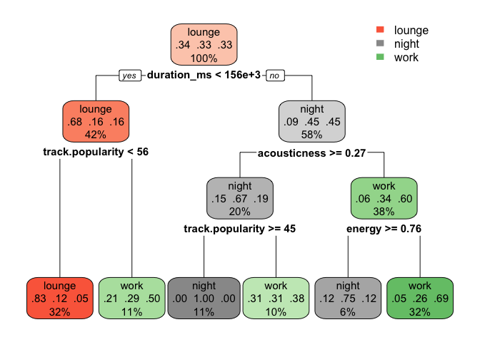

```r
library(rpart.plot)
rpart.plot(tree$finalModel)
```

Next, the feature importances of the decision tree were analyzed. The importances are stored into a dataframe titled importance.

```r
importance <- varImp(tree, scale=FALSE)
```

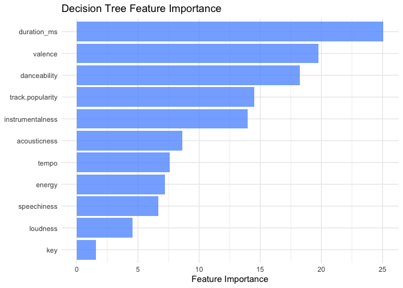

```r
importance$importance %>%
  mutate(feature = rownames(importance$importance)) %>%
  filter(Overall > 0) %>%
  ggplot(aes(
    x = reorder(feature,Overall),
    y= Overall
  )) +
  geom_bar(stat="identity", position="dodge",fill="#619CFF", alpha = 0.8) +
  ylab("Feature Importance") +
  coord_flip() +
  theme_minimal() +
  theme(
    axis.title.y = element_blank()
  ) +
  ggtitle("Decision Tree Feature Importance")
```